# Credit EDA Assignment Solution

## Segregating the dataset on Target=0 and Target=1

```python
train_0 = application_data.loc[application_data['TARGET'] == 0] # 0 - Loan was repaid
train_1 = application_data.loc[application_data['TARGET'] == 1] # 1 - Loan was not repaid
```

```
Plot of AMT_INCOME_TOTAL
```

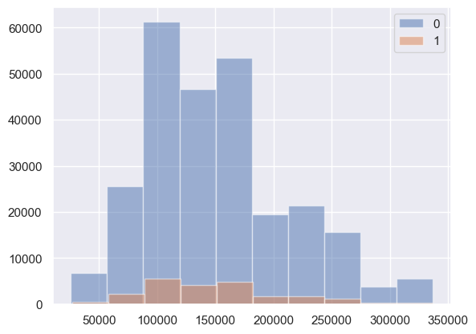

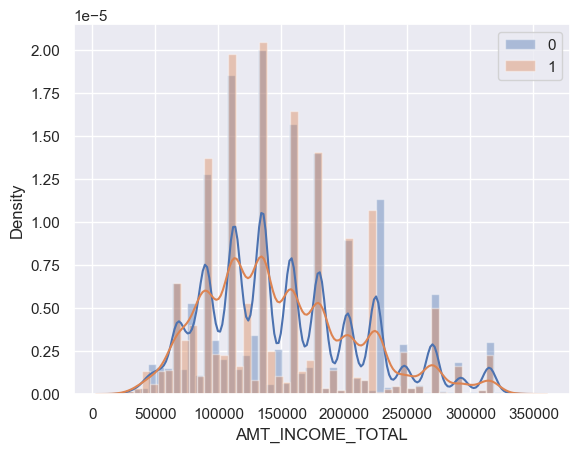

```
------------------------------------------------------------------------
Plot of AMT_CREDIT
```

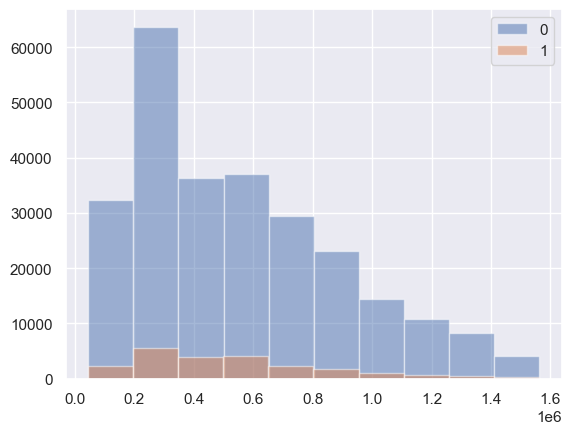

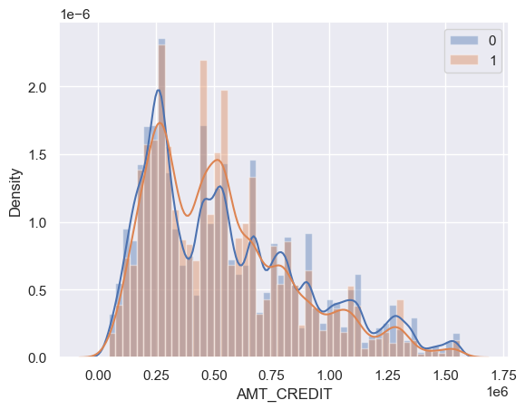

```
------------------------------------------------------------------------
Plot of AMT_ANNUITY
```

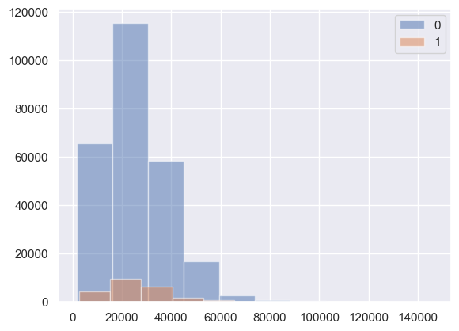

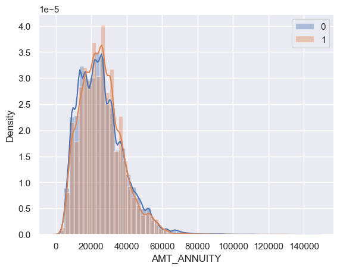

```
------------------------------------------------------------------------
Plot of AMT_GOODS_PRICE
```

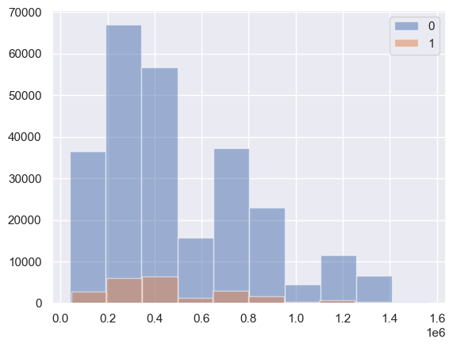

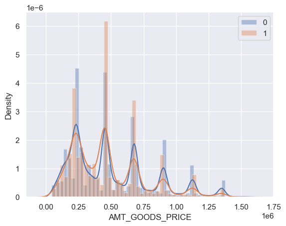

```
------------------------------------------------------------------------
Plot of CNT_FAM_MEMBERS
```

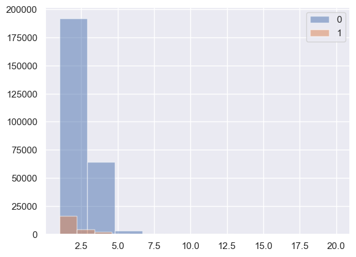

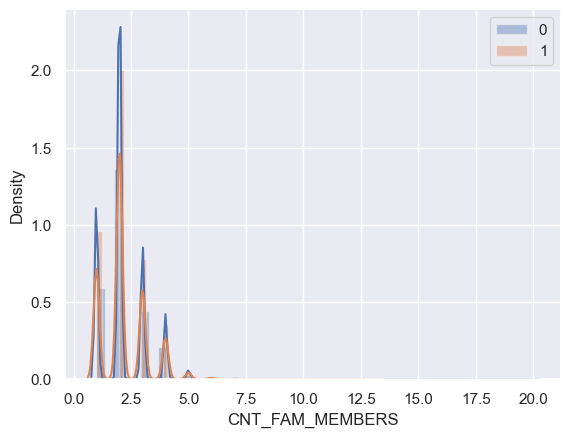

```python
for column in num_col_anlysis:
    title = "Plot of "+column
    print(title)
    plt.hist(train_0[column], alpha=0.5, label='0') # plotting a histogram for target 0 i.e. loan was repaid
    plt.hist(train_1[column], alpha=0.5, label='1') # plotting a histogram for target 1 i.e. loan was not repaid
    plt.legend()
    plt.show()

    sns.distplot(train_0[column], label='0') # plotting a distribution plot for target 0 i.e. loan was repaid
    sns.distplot(train_1[column],  label='1') # plotting a distribution plot for target 1 i.e. loan was not repaid
    plt.legend()
    plt.show()
    print("------------------------------------------------------------------------")
```

# Insights

I have considered dist plot to give the insights

### AMT_INCOME_TOTAL

- The income type for both targeted type lied around 1000000 to 150000

### AMT_ANNUITY

- Most client pay an annuity below 60K for their credit loans.

### AMT_GOODS_PRICE

- The majority of loans are granted for goods prices below 1M.

### CNT_FAM_MEMBERS

- the mojority of family members have size < 3 have difficult to repay the loan

# Bivariate & Multivariate Analysis

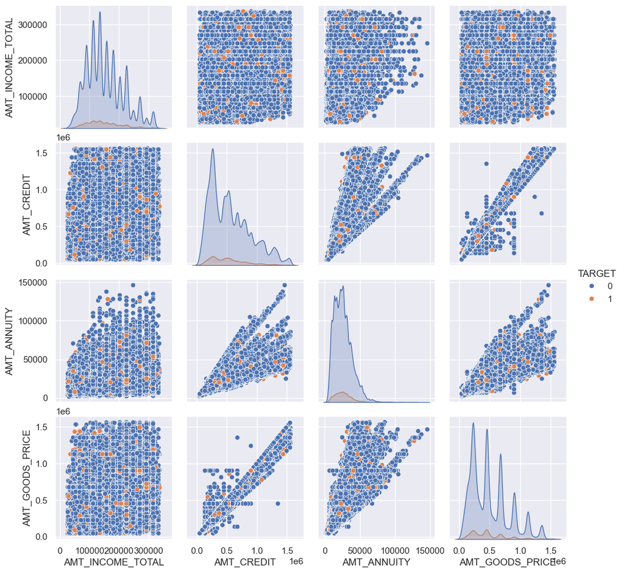

```python
# Create a pairplot with hue as 'TARGET'
sns.pairplot(data = application_data, vars = [ 'AMT_INCOME_TOTAL','AMT_CREDIT','AMT_ANNUITY', 'AMT_GOODS_PRICE'], hue = 'TARGET', diag_kind='kde')
```

## Previous Application

```python
previous_data = pd.read_csv("previous_application.csv")
```

```python
previous_data.head()
```

|  | SK_ID_PREV | SK_ID_CURR | NAME_CONTRACT_TYPE | AMT_ANNUITY | AMT_APPLICATION | AMT_CREDIT | AMT_DOWN_PAYMENT | AMT_GOODS_PRICE | WEEKDAY_APPR_PROCESS_START | HOUR_APPR_PROCESS_START | FLAG_LAST_APPL_PER_CONTRACT | NFLAG_LAST_APPL_IN_DAY | RATE_DOWN_PAYMENT | RATE_INTEREST_PRIMARY | RATE_INTEREST_PRIVILEGED | NAME_CASH_LOAN_PURPOSE | NAME_CONTRACT_STATUS | DAYS_DECISION | NAME_PAYMENT_TYPE | CODE_REJECT_REASON | NAME_TYPE_SUITE | NAME_CLIENT_TYPE | NAME_GOODS_CATEGORY | NAME_PORTFOLIO | NAME_PRODUCT_TYPE | CHANNEL_TYPE | SELLERPLACE_AREA | NAME_SELLER_INDUSTRY | CNT_PAYMENT | … |
| --- | --- | --- | --- | --- | --- | --- | --- | --- | --- | --- | --- | --- | --- | --- | --- | --- | --- | --- | --- | --- | --- | --- | --- | --- | --- | --- | --- | --- | --- | --- |
| 0 | 2030495 | 271877 | Consumer loans | 1730.430 | 17145.0 | 17145.0 | 0.0 | 17145.0 | SATURDAY | 15 | Y | 1 | 0.0 | 0.182832 | 0.867336 | XAP | Approved | -73 | Cash through the bank | XAP | NaN | Repeater | Mobile | POS | XNA | Country-wide | 35 | Connectivity | 12.0 | … |
| 1 | 2802425 | 108129 | Cash loans | 25188.615 | 607500.0 | 679671.0 | NaN | 607500.0 | THURSDAY | 11 | Y | 1 | NaN | NaN | NaN | XNA | Approved | -164 | XNA | XAP | Unaccompanied | Repeater | XNA | Cash | x-sell | Contact center | -1 | XNA | 36.0 | … |
| 2 | 2523466 | 122040 | Cash loans | 15060.735 | 112500.0 | 136444.5 | NaN | 112500.0 | TUESDAY | 11 | Y | 1 | NaN | NaN | NaN | XNA | Approved | -301 | Cash through the bank | XAP | Spouse, partner | Repeater | XNA | Cash | x-sell | Credit and cash offices | -1 | XNA | 12.0 | … |
| 3 | 2819243 | 176158 | Cash loans | 47041.335 | 450000.0 | 470790.0 | NaN | 450000.0 | MONDAY | 7 | Y | 1 | NaN | NaN | NaN | XNA | Approved | -512 | Cash through the bank | XAP | NaN | Repeater | XNA | Cash | x-sell | Credit and cash offices | -1 | XNA | 12.0 | … |
| 4 | 1784265 | 202054 | Cash loans | 31924.395 | 337500.0 | 404055.0 | NaN | 337500.0 | THURSDAY | 9 | Y | 1 | NaN | NaN | NaN | Repairs | Refused | -781 | Cash through the bank | HC | NaN | Repeater | XNA | Cash | walk-in | Credit and cash offices | -1 | XNA | 24.0 | … |

```python
previous_data.shape
```

```
(1670214, 37)
```

```python
previous_data.info()
```

```
<class 'pandas.core.frame.DataFrame'>
RangeIndex: 1670214 entries, 0 to 1670213
Data columns (total 37 columns):
 #   Column                       Non-Null Count    Dtype
---  ------                       --------------    -----
 0   SK_ID_PREV                   1670214 non-null  int64
 1   SK_ID_CURR                   1670214 non-null  int64
 2   NAME_CONTRACT_TYPE           1670214 non-null  object
 3   AMT_ANNUITY                  1297979 non-null  float64
 4   AMT_APPLICATION              1670214 non-null  float64
 5   AMT_CREDIT                   1670213 non-null  float64
 6   AMT_DOWN_PAYMENT             774370 non-null   float64
 7   AMT_GOODS_PRICE              1284699 non-null  float64
 8   WEEKDAY_APPR_PROCESS_START   1670214 non-null  object
 9   HOUR_APPR_PROCESS_START      1670214 non-null  int64
```

[output cut: 29 more lines]

```python
# shows how much percentage of data are null
null_col = (previous_data.isnull().sum()/previous_data.shape[0]*100).sort_values(ascending = False)
null_col[null_col>0]
```

```
RATE_INTEREST_PRIVILEGED     99.643698
RATE_INTEREST_PRIMARY        99.643698
AMT_DOWN_PAYMENT             53.636480
RATE_DOWN_PAYMENT            53.636480
NAME_TYPE_SUITE              49.119754
NFLAG_INSURED_ON_APPROVAL    40.298129
DAYS_TERMINATION             40.298129
DAYS_LAST_DUE                40.298129
DAYS_LAST_DUE_1ST_VERSION    40.298129
DAYS_FIRST_DUE               40.298129
DAYS_FIRST_DRAWING           40.298129
AMT_GOODS_PRICE              23.081773
AMT_ANNUITY                  22.286665
CNT_PAYMENT                  22.286366
PRODUCT_COMBINATION           0.020716
AMT_CREDIT                    0.000060
dtype: float64
```

```python
# Lets See the columns who has more than 40 % of data with Null values
cut_off=40
cols_to_drop=list(previous_data.columns[100*previous_data.isnull().mean()>cut_off])
print(cols_to_drop)
```

```
['AMT_DOWN_PAYMENT', 'RATE_DOWN_PAYMENT', 'RATE_INTEREST_PRIMARY', 'RATE_INTEREST_PRIVILEGED', 'NAME_TYPE_SUITE', 'DAYS_FIRST_DRAWING', 'DAYS_FIRST_DUE', 'DAYS_LAST_DUE_1ST_VERSION', 'DAYS_LAST_DUE', 'DAYS_TERMINATION', 'NFLAG_INSURED_ON_APPROVAL']
```

```python
len(cols_to_drop)
```

```
11
```

```python
previous_data.drop(columns= cols_to_drop, axis= 1, inplace= True)
```

```python
previous_data.shape
```

```
(1670214, 26)
```

```python
# shows how much percentage of data are null
null_col = (previous_data.isnull().sum()/previous_data.shape[0]*100).sort_values(ascending = False)
null_col[null_col>0]
```

```
AMT_GOODS_PRICE        23.081773
AMT_ANNUITY            22.286665
CNT_PAYMENT            22.286366
PRODUCT_COMBINATION     0.020716
AMT_CREDIT              0.000060
dtype: float64
```

```python
previous_data[['AMT_GOODS_PRICE','AMT_ANNUITY','CNT_PAYMENT','PRODUCT_COMBINATION','AMT_CREDIT']]
```

|  | AMT_GOODS_PRICE | AMT_ANNUITY | CNT_PAYMENT | PRODUCT_COMBINATION | AMT_CREDIT |
| --- | --- | --- | --- | --- | --- |
| 0 | 17145.0 | 1730.430 | 12.0 | POS mobile with interest | 17145.0 |
| 1 | 607500.0 | 25188.615 | 36.0 | Cash X-Sell: low | 679671.0 |
| 2 | 112500.0 | 15060.735 | 12.0 | Cash X-Sell: high | 136444.5 |
| 3 | 450000.0 | 47041.335 | 12.0 | Cash X-Sell: middle | 470790.0 |
| 4 | 337500.0 | 31924.395 | 24.0 | Cash Street: high | 404055.0 |
| ... | ... | ... | ... | ... | ... |
| 1670209 | 267295.5 | 14704.290 | 30.0 | POS industry with interest | 311400.0 |
| 1670210 | 87750.0 | 6622.020 | 12.0 | POS industry with interest | 64291.5 |
| 1670211 | 105237.0 | 11520.855 | 10.0 | POS household with interest | 102523.5 |
| 1670212 | 180000.0 | 18821.520 | 12.0 | Cash X-Sell: low | 191880.0 |
| 1670213 | 360000.0 | 16431.300 | 48.0 | Cash X-Sell: middle | 360000.0 |

1670214 rows × 5 columns

# Data Cleaning On Previous Application Data

```python
#pd.set_option("display.max_rows",None)
# displaying only columns having null values which is greater than 0
Null_columns = previous_data.count()/len(previous_data)
Null_columns = (1- Null_columns)*100
Null_columns[Null_columns>0].sort_values()
```

```
AMT_CREDIT              0.000060
PRODUCT_COMBINATION     0.020716
CNT_PAYMENT            22.286366
AMT_ANNUITY            22.286665
AMT_GOODS_PRICE        23.081773
dtype: float64
```

## 1. PRODUCT_COMBINATION

```python
previous_data['PRODUCT_COMBINATION'].value_counts()
```

```
PRODUCT_COMBINATION
Cash                              285990
POS household with interest       263622
POS mobile with interest          220670
Cash X-Sell: middle               143883
Cash X-Sell: low                  130248
Card Street                       112582
POS industry with interest         98833
POS household without interest     82908
Card X-Sell                        80582
Cash Street: high                  59639
Cash X-Sell: high                  59301
Cash Street: middle                34658
Cash Street: low                   33834
POS mobile without interest        24082
POS other with interest            23879
POS industry without interest      12602
POS others without interest         2555
Name: count, dtype: int64
```

We change the production combination null values wih mode as percentage of null values are very less we can replace it with a mode

```python
previous_data['PRODUCT_COMBINATION'].fillna(previous_data['PRODUCT_COMBINATION'].mode()[0],  inplace= True)
```

```python
#pd.set_option("display.max_rows",None)
# displaying only columns having null values which is greater than 0
Null_columns = previous_data.count()/len(previous_data)
Null_columns = (1- Null_columns)*100
Null_columns[Null_columns>0].sort_values()
```

```
AMT_CREDIT          0.000060
CNT_PAYMENT        22.286366
AMT_ANNUITY        22.286665
AMT_GOODS_PRICE    23.081773
dtype: float64
```

```python
Null_columns = previous_data[['AMT_GOODS_PRICE','AMT_ANNUITY','CNT_PAYMENT','AMT_CREDIT']]
```

Lets see the histogram fro all null columns and then fill the null values with approprimate values

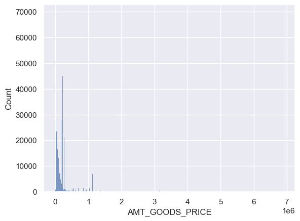

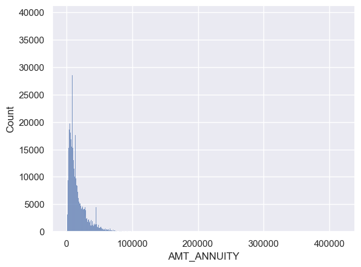

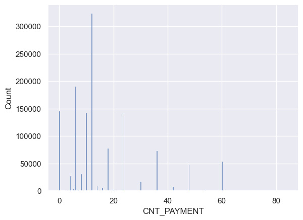

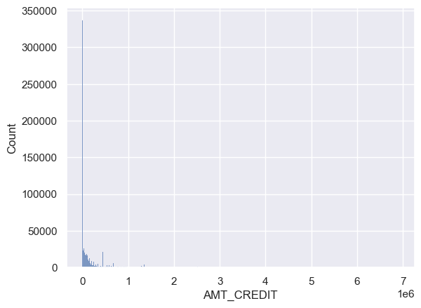

```python
for col in Null_columns:
    sns.histplot(previous_data, x = col)
    plt.show()
```

Seams all of them are right skewed its better to fill all null values with median

```python
for col in Null_columns:
    med = previous_data[col].median()
    previous_data[col] = previous_data[col].fillna(med)
```

```python
#pd.set_option("display.max_rows",None)
# displaying only columns having null values which is greater than 0
Null_columns = previous_data.count()/len(previous_data)
Null_columns = (1- Null_columns)*100
Null_columns[Null_columns>0].sort_values()
```

```
Series([], dtype: float64)
```

## Previous Application Data

```python
previous_data.head()
```

|  | SK_ID_PREV | SK_ID_CURR | NAME_CONTRACT_TYPE | AMT_ANNUITY | AMT_APPLICATION | AMT_CREDIT | AMT_GOODS_PRICE | WEEKDAY_APPR_PROCESS_START | HOUR_APPR_PROCESS_START | FLAG_LAST_APPL_PER_CONTRACT | NFLAG_LAST_APPL_IN_DAY | NAME_CASH_LOAN_PURPOSE | NAME_CONTRACT_STATUS | DAYS_DECISION | NAME_PAYMENT_TYPE | CODE_REJECT_REASON | NAME_CLIENT_TYPE | NAME_GOODS_CATEGORY | NAME_PORTFOLIO | NAME_PRODUCT_TYPE | CHANNEL_TYPE | SELLERPLACE_AREA | NAME_SELLER_INDUSTRY | CNT_PAYMENT | NAME_YIELD_GROUP | PRODUCT_COMBINATION |
| --- | --- | --- | --- | --- | --- | --- | --- | --- | --- | --- | --- | --- | --- | --- | --- | --- | --- | --- | --- | --- | --- | --- | --- | --- | --- | --- |
| 0 | 2030495 | 271877 | Consumer loans | 1730.430 | 17145.0 | 17145.0 | 17145.0 | SATURDAY | 15 | Y | 1 | XAP | Approved | -73 | Cash through the bank | XAP | Repeater | Mobile | POS | XNA | Country-wide | 35 | Connectivity | 12.0 | middle | POS mobile with interest |
| 1 | 2802425 | 108129 | Cash loans | 25188.615 | 607500.0 | 679671.0 | 607500.0 | THURSDAY | 11 | Y | 1 | XNA | Approved | -164 | XNA | XAP | Repeater | XNA | Cash | x-sell | Contact center | -1 | XNA | 36.0 | low_action | Cash X-Sell: low |
| 2 | 2523466 | 122040 | Cash loans | 15060.735 | 112500.0 | 136444.5 | 112500.0 | TUESDAY | 11 | Y | 1 | XNA | Approved | -301 | Cash through the bank | XAP | Repeater | XNA | Cash | x-sell | Credit and cash offices | -1 | XNA | 12.0 | high | Cash X-Sell: high |
| 3 | 2819243 | 176158 | Cash loans | 47041.335 | 450000.0 | 470790.0 | 450000.0 | MONDAY | 7 | Y | 1 | XNA | Approved | -512 | Cash through the bank | XAP | Repeater | XNA | Cash | x-sell | Credit and cash offices | -1 | XNA | 12.0 | middle | Cash X-Sell: middle |
| 4 | 1784265 | 202054 | Cash loans | 31924.395 | 337500.0 | 404055.0 | 337500.0 | THURSDAY | 9 | Y | 1 | Repairs | Refused | -781 | Cash through the bank | HC | Repeater | XNA | Cash | walk-in | Credit and cash offices | -1 | XNA | 24.0 | high | Cash Street: high |

```python
previous_data['NAME_CONTRACT_TYPE'].value_counts()
```

```
NAME_CONTRACT_TYPE
Cash loans         747553
Consumer loans     729151
Revolving loans    193164
XNA                   346
Name: count, dtype: int64
```

```python
previous_data['NAME_CONTRACT_STATUS'].value_counts()
```

```
NAME_CONTRACT_STATUS
Approved        1036781
Canceled         316319
Refused          290678
Unused offer      26436
Name: count, dtype: int64
```

```python
previous_data['NAME_CASH_LOAN_PURPOSE'].value_counts()
```

```
NAME_CASH_LOAN_PURPOSE
XAP                                 922661
XNA                                 677918
Repairs                              23765
Other                                15608
Urgent needs                          8412
Buying a used car                     2888
Building a house or an annex          2693
Everyday expenses                     2416
Medicine                              2174
Payments on other loans               1931
Education                             1573
Journey                               1239
Purchase of electronic equipment      1061
Buying a new car                      1012
Wedding / gift / holiday               962
Buying a home                          865
Car repairs                            797
Furniture                              749
Buying a holiday home / land           533
Business development                   426
Gasification / water supply            300
Buying a garage                        136
Hobby                                   55
Money for a third person                25
Refusal to name the goal                15
Name: count, dtype: int64
```

lets change days to year in DAYS_DECISION columns beacuse cant be negative and standardise into year

```python
previous_data['YEAR_DECISION'] =previous_data['DAYS_DECISION'].abs()// 365
```

```python
previous_data.head()
```

|  | SK_ID_PREV | SK_ID_CURR | NAME_CONTRACT_TYPE | AMT_ANNUITY | AMT_APPLICATION | AMT_CREDIT | AMT_GOODS_PRICE | WEEKDAY_APPR_PROCESS_START | HOUR_APPR_PROCESS_START | FLAG_LAST_APPL_PER_CONTRACT | NFLAG_LAST_APPL_IN_DAY | NAME_CASH_LOAN_PURPOSE | NAME_CONTRACT_STATUS | DAYS_DECISION | NAME_PAYMENT_TYPE | CODE_REJECT_REASON | NAME_CLIENT_TYPE | NAME_GOODS_CATEGORY | NAME_PORTFOLIO | NAME_PRODUCT_TYPE | CHANNEL_TYPE | SELLERPLACE_AREA | NAME_SELLER_INDUSTRY | CNT_PAYMENT | NAME_YIELD_GROUP | PRODUCT_COMBINATION | YEAR_DECISION |
| --- | --- | --- | --- | --- | --- | --- | --- | --- | --- | --- | --- | --- | --- | --- | --- | --- | --- | --- | --- | --- | --- | --- | --- | --- | --- | --- | --- |
| 0 | 2030495 | 271877 | Consumer loans | 1730.430 | 17145.0 | 17145.0 | 17145.0 | SATURDAY | 15 | Y | 1 | XAP | Approved | -73 | Cash through the bank | XAP | Repeater | Mobile | POS | XNA | Country-wide | 35 | Connectivity | 12.0 | middle | POS mobile with interest | 0 |
| 1 | 2802425 | 108129 | Cash loans | 25188.615 | 607500.0 | 679671.0 | 607500.0 | THURSDAY | 11 | Y | 1 | XNA | Approved | -164 | XNA | XAP | Repeater | XNA | Cash | x-sell | Contact center | -1 | XNA | 36.0 | low_action | Cash X-Sell: low | 0 |
| 2 | 2523466 | 122040 | Cash loans | 15060.735 | 112500.0 | 136444.5 | 112500.0 | TUESDAY | 11 | Y | 1 | XNA | Approved | -301 | Cash through the bank | XAP | Repeater | XNA | Cash | x-sell | Credit and cash offices | -1 | XNA | 12.0 | high | Cash X-Sell: high | 0 |
| 3 | 2819243 | 176158 | Cash loans | 47041.335 | 450000.0 | 470790.0 | 450000.0 | MONDAY | 7 | Y | 1 | XNA | Approved | -512 | Cash through the bank | XAP | Repeater | XNA | Cash | x-sell | Credit and cash offices | -1 | XNA | 12.0 | middle | Cash X-Sell: middle | 1 |
| 4 | 1784265 | 202054 | Cash loans | 31924.395 | 337500.0 | 404055.0 | 337500.0 | THURSDAY | 9 | Y | 1 | Repairs | Refused | -781 | Cash through the bank | HC | Repeater | XNA | Cash | walk-in | Credit and cash offices | -1 | XNA | 24.0 | high | Cash Street: high | 2 |

```python
previous_data.drop(columns= ['DAYS_DECISION'], axis =1 , inplace = True)
```

```python
previous_data['NAME_YIELD_GROUP'].value_counts()
```

```
NAME_YIELD_GROUP
XNA           517215
middle        385532
high          353331
low_normal    322095
low_action     92041
Name: count, dtype: int64
```

## Data Visualization on Previous Application Data

```python
preanalysis_col = ['NAME_CONTRACT_TYPE','NAME_CONTRACT_STATUS','NAME_CLIENT_TYPE']
```

```python
def prev_app_analysis(data, columns):
    plt.figure(figsize=(8, 6))
    ax1 = plt.subplot(1,2,2)
    previous_data[columns].value_counts().plot.pie(autopct = "%1.0f%%",ax = ax1)
    plt.xlabel(columns)
    plt.axis('equal')
    plt.title('Distribution of' +" "+ columns)
    plt.xticks(rotation=90)
    plt.show()
```

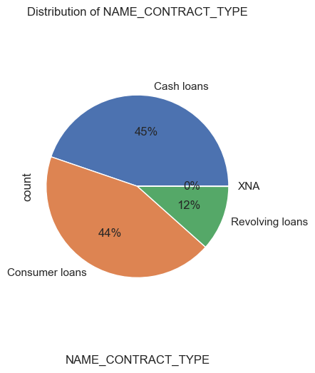

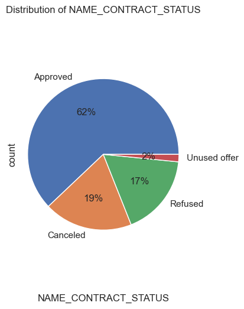

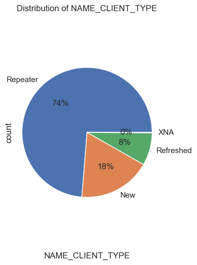

```python
for col in preanalysis_col:
    prev_app_analysis(preanalysis_col, col)
```

## Insights On Previous Application

## 1. Name Contract Type

1. Cash loans: The most common contract type, accounting for 45% of all contracts.
2. Consumer loans: A significant portion of contracts, making up 44% of the total.
3. Revolving loans: Less common, representing 12% of contracts. Typically associated with credit cards or lines of credit.
4. There is 0 % of XNA category

### 2. Name Contract Status

1. The majority of loan applications were successfully approved ie 62% approved loan..
2. Approximately 19% of applicants canceled their loan requests
3. About 17% of applications werrefuseded, highlighting the importance of assessing rejection criteria and applicant profile
4. A small percentage received offers but didn’t proceed, warranting investigation into factors influencing this decisiosks.

## Merging the application Data and previous application data

```python
data_final = application_data.merge(previous_data, left_on='SK_ID_CURR',
                                         right_on='SK_ID_CURR', how='inner')
```

```python
data_final.head()
```

|  | SK_ID_CURR | TARGET | NAME_CONTRACT_TYPE_x | CODE_GENDER | CNT_CHILDREN | AMT_INCOME_TOTAL | AMT_CREDIT_x | AMT_ANNUITY_x | AMT_GOODS_PRICE_x | NAME_TYPE_SUITE | NAME_INCOME_TYPE | NAME_EDUCATION_TYPE | NAME_FAMILY_STATUS | NAME_HOUSING_TYPE | REGION_POPULATION_RELATIVE | OCCUPATION_TYPE | CNT_FAM_MEMBERS | REGION_RATING_CLIENT | REGION_RATING_CLIENT_W_CITY | WEEKDAY_APPR_PROCESS_START_x | HOUR_APPR_PROCESS_START_x | REG_REGION_NOT_LIVE_REGION | REG_REGION_NOT_WORK_REGION | LIVE_REGION_NOT_WORK_REGION | REG_CITY_NOT_LIVE_CITY | REG_CITY_NOT_WORK_CITY | LIVE_CITY_NOT_WORK_CITY | ORGANIZATION_TYPE | OBS_30_CNT_SOCIAL_CIRCLE | … |
| --- | --- | --- | --- | --- | --- | --- | --- | --- | --- | --- | --- | --- | --- | --- | --- | --- | --- | --- | --- | --- | --- | --- | --- | --- | --- | --- | --- | --- | --- | --- |
| 0 | 100002 | 1 | Cash loans | M | 0 | 202500.0 | 406597.5 | 24700.5 | 351000.0 | Unaccompanied | Working | Secondary | Single | House | 0.018801 | Laborers | 1 | 2 | 2 | WEDNESDAY | 10 | 0 | 0 | 0 | 0 | 0 | 0 | Business Entity Type 3 | 2.0 | … |
| 1 | 100003 | 0 | Cash loans | F | 0 | 270000.0 | 1293502.5 | 35698.5 | 1129500.0 | Family | State servant | Higher education | Married | House | 0.003541 | Core staff | 2 | 1 | 1 | MONDAY | 11 | 0 | 0 | 0 | 0 | 0 | 0 | School | 1.0 | … |
| 2 | 100003 | 0 | Cash loans | F | 0 | 270000.0 | 1293502.5 | 35698.5 | 1129500.0 | Family | State servant | Higher education | Married | House | 0.003541 | Core staff | 2 | 1 | 1 | MONDAY | 11 | 0 | 0 | 0 | 0 | 0 | 0 | School | 1.0 | … |
| 3 | 100003 | 0 | Cash loans | F | 0 | 270000.0 | 1293502.5 | 35698.5 | 1129500.0 | Family | State servant | Higher education | Married | House | 0.003541 | Core staff | 2 | 1 | 1 | MONDAY | 11 | 0 | 0 | 0 | 0 | 0 | 0 | School | 1.0 | … |
| 4 | 100004 | 0 | Revolving loans | M | 0 | 67500.0 | 135000.0 | 6750.0 | 135000.0 | Unaccompanied | Working | Secondary | Single | House | 0.010032 | Laborers | 1 | 2 | 2 | MONDAY | 9 | 0 | 0 | 0 | 0 | 0 | 0 | Government | 0.0 | … |

```python
data_final.shape
```

```
(1292479, 72)
```

```python
data_final.columns.values
```

```
array(['SK_ID_CURR', 'TARGET', 'NAME_CONTRACT_TYPE_x', 'CODE_GENDER',
       'CNT_CHILDREN', 'AMT_INCOME_TOTAL', 'AMT_CREDIT_x',
       'AMT_ANNUITY_x', 'AMT_GOODS_PRICE_x', 'NAME_TYPE_SUITE',
       'NAME_INCOME_TYPE', 'NAME_EDUCATION_TYPE', 'NAME_FAMILY_STATUS',
       'NAME_HOUSING_TYPE', 'REGION_POPULATION_RELATIVE',
       'OCCUPATION_TYPE', 'CNT_FAM_MEMBERS', 'REGION_RATING_CLIENT',
       'REGION_RATING_CLIENT_W_CITY', 'WEEKDAY_APPR_PROCESS_START_x',
       'HOUR_APPR_PROCESS_START_x', 'REG_REGION_NOT_LIVE_REGION',
       'REG_REGION_NOT_WORK_REGION', 'LIVE_REGION_NOT_WORK_REGION',
       'REG_CITY_NOT_LIVE_CITY', 'REG_CITY_NOT_WORK_CITY',
       'LIVE_CITY_NOT_WORK_CITY', 'ORGANIZATION_TYPE',
       'OBS_30_CNT_SOCIAL_CIRCLE', 'DEF_30_CNT_SOCIAL_CIRCLE',
       'OBS_60_CNT_SOCIAL_CIRCLE', 'DEF_60_CNT_SOCIAL_CIRCLE',
       'AMT_REQ_CREDIT_BUREAU_HOUR', 'AMT_REQ_CREDIT_BUREAU_DAY',
       'AMT_REQ_CREDIT_BUREAU_WEEK', 'AMT_REQ_CREDIT_BUREAU_MON',
       'AMT_REQ_CREDIT_BUREAU_QRT', 'AMT_REQ_CREDIT_BUREAU_YEAR',
       'YEAR_LAST_PHONE_CHANGE', 'YEAR_REGISTRATION', 'AGE',
       'YEAR_EMPLOYED', 'YEAR_ID_PUBLISH', 'All_Flag_document', 'Age',
       'AMT_INCOME_GROUP', 'AMT_CREDIT_GROUP', 'SK_ID_PREV',
       'NAME_CONTRACT_TYPE_y', 'AMT_ANNUITY_y', 'AMT_APPLICATION',
       'AMT_CREDIT_y', 'AMT_GOODS_PRICE_y',
       'WEEKDAY_APPR_PROCESS_START_y', 'HOUR_APPR_PROCESS_START_y',
       'FLAG_LAST_APPL_PER_CONTRACT', 'NFLAG_LAST_APPL_IN_DAY',
       'NAME_CASH_LOAN_PURPOSE', 'NAME_CONTRACT_STATUS',
       'NAME_PAYMENT_TYPE', 'CODE_REJECT_REASON', 'NAME_CLIENT_TYPE',
       'NAME_GOODS_CATEGORY', 'NAME_PORTFOLIO', 'NAME_PRODUCT_TYPE',
       'CHANNEL_TYPE', 'SELLERPLACE_AREA', 'NAME_SELLER_INDUSTRY',
       'CNT_PAYMENT', 'NAME_YIELD_GROUP', 'PRODUCT_COMBINATION',
       'YEAR_DECISION'], dtype=object)
```

```python
train_0 = application_data.loc[application_data['TARGET'] == 0] # train_0 - It contains the data where the loan was repaid
train_1 = application_data.loc[application_data['TARGET'] == 1] # train_1 - It contains the data where the loan was not repaid
```

```python
ptrain_0 = data_final.loc[data_final['TARGET'] == 0]  # ptrain_0 - It contains the data where the loan was repaid
ptrain_1 = data_final.loc[data_final['TARGET'] == 1] # ptrain_1 - It contains the data where the loan was not repaid
```

```python
def plotting(column, hue):
    col = column
    hue = hue
    fig = plt.figure(figsize=(13,10))

    ax1 = plt.subplot(221)
    application_data[col].value_counts().plot.pie(autopct = "%1.0f%%", ax=ax1) # autopct is used to show the percentage on the pie chart
    plt.title('Plotting data for the column: '+ column)

    ax2 = plt.subplot(222)
    df = pd.DataFrame()
    df['0']= ((train_0[col].value_counts())/len(train_0))
    df['1']= ((train_1[col].value_counts())/len(train_1))
    df.plot.bar(ax=ax2) # plotting the bar chart
    plt.title('Plotting data for target in terms of total count')


    ax3 = plt.subplot(223)
    sns.countplot(x=col, hue=hue, data=ptrain_0, ax = ax3) # plotting the countplot
    plt.xticks(rotation=90)
    plt.title('Plotting data for Target=0 in terms of percentage')

    ax4 = plt.subplot(224)
    sns.countplot(x=col, hue=hue, data=ptrain_1, ax = ax4) # plotting the countplot
    plt.xticks(rotation=90)
    plt.title('Plotting data for Target=1 in terms of percentage')



    fig.tight_layout() # Or equivalently,  "plt.tight_layout()"

    plt.show()
```

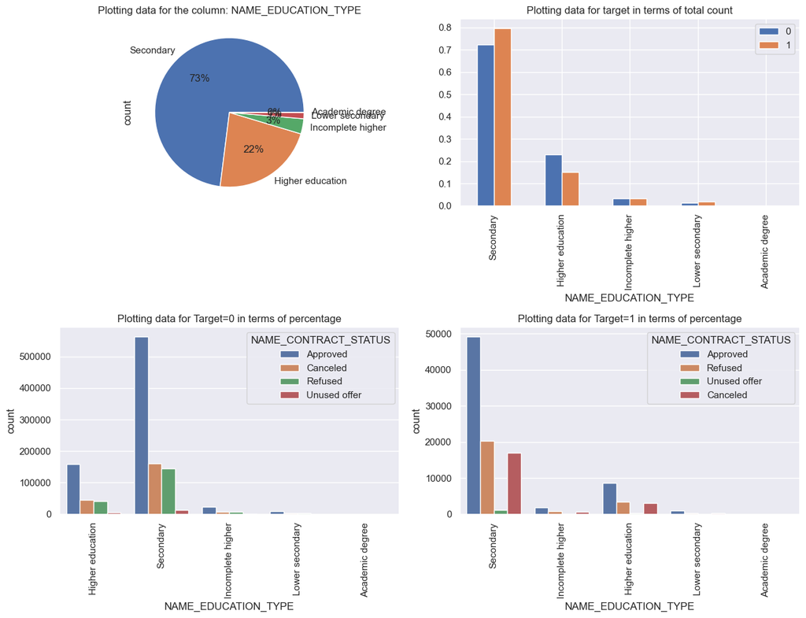

```python
plotting('NAME_EDUCATION_TYPE','NAME_CONTRACT_STATUS')
```

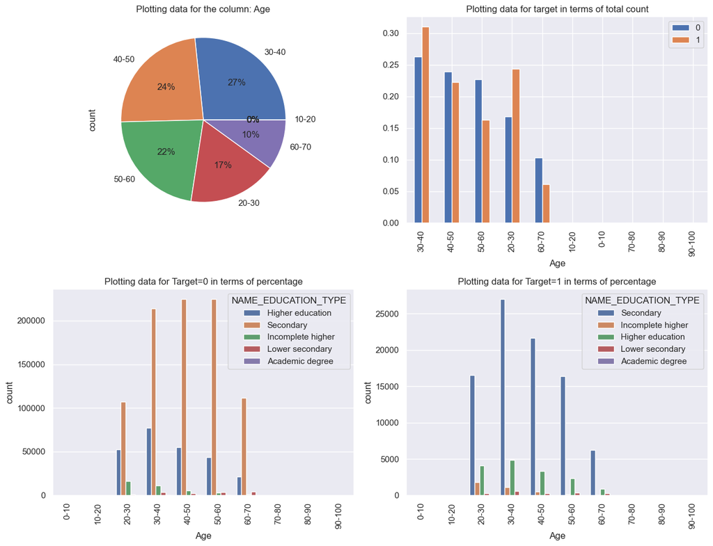

```python
plotting('Age','NAME_EDUCATION_TYPE')
```